# WMSS Teacher Survey Analysis - Spring 2017

WMSS

2017-04-30

The purpose of the survey was to provide valuable information about the digital tools used in the classroom, the digital projects that are created or would like to be created by students, and the digital needs of both teachers and students.

The survey can be found at here: [WMSS Teacher Technology Survey - Spring 2017](https://forms.office.com/Pages/ResponsePage.aspx?id=LGaFrd9pi0iFpI7ChwIywBwOEpdW4ixFvc3sphI3BmxUOTk2RDdKVFVMTUowUkk4WVhZQkpXSDJPRC4u)

The raw survey results used in this analysis can be found here: [Survey_Results.xlxs](https://www.dropbox.com/s/g73h8qny4pqgwvv/Survey_Results.xlsx?dl=0)

This study is done in a reproducible research manner. All statistical analysis and figures below were created in the open source software package R.

The code used to produce this anlysis can be found here: [Analysis.Rmd](https://www.dropbox.com/s/h18fc4ely70owxj/Analysis.Rmd?dl=0)

For the sake of common language, the following term definitions are provided:

**Digital Tools:**

Any of the applications on Launchpad that the district has put in place/purchased

**Digital Projects:**

Any visible or tangible creations that are made by students using technology

**Digital Needs:**

What specific training or programs do you need?

## Summary

Number of Responses as of 2017-04-30: **28**

## Question 1

**What barriers prohibit you from incorporating technology use into your classroom?**

| Q1 Answers | Frequency | Percentage |
| --- | --- | --- |
| Not enough devices available | 17 | 0.61 |
| Need support with connections/devices/technology issues | 12 | 0.43 |
| Need more time to develop technology-based lessons after support | 10 | 0.36 |
| Need more technology support | 5 | 0.18 |
| just getting everyone logged on with their own account. They have to type in @brevardschools.org everytime they need Launchpad. | 1 | 0.04 |
| Need grade level appropriate technology | 1 | 0.04 |
| Not in classroom | 1 | 0.04 |
| Since students are younger, having to login to every single device’s wifi. | 1 | 0.04 |
| we have mutiple computers but sometimes testing limits labs | 1 | 0.04 |

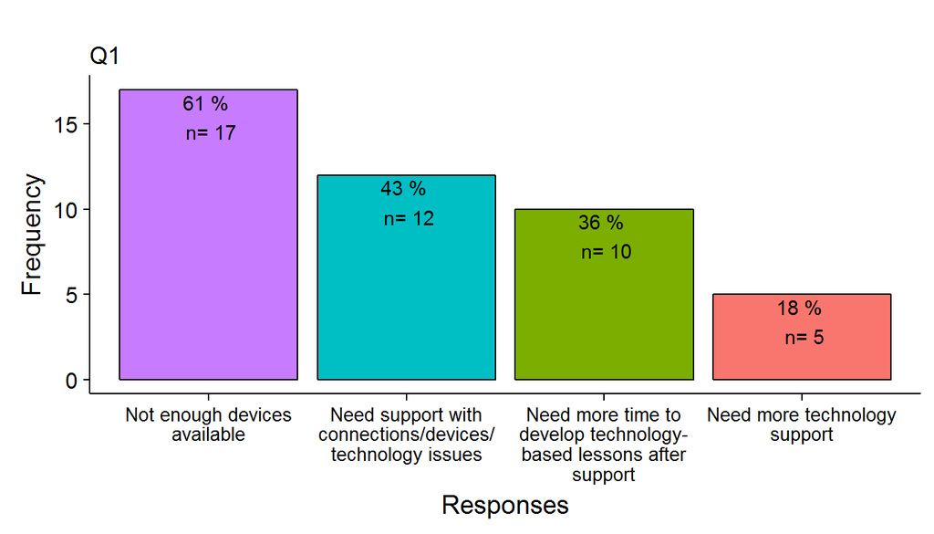

## Question 2

**Would you incorporate the use of technology in the classroom more often if your students had individual access to a laptop every day (one to one ratio)?**

| Q2 Answers | Frequency | Percentage |
| --- | --- | --- |
| Definitely | 24 | 0.86 |
| Most likely | 4 | 0.14 |

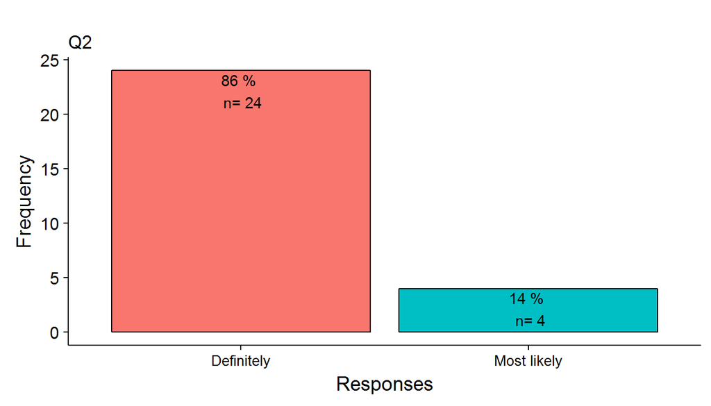

## Question 3

**Which of the following BPS supported Digital Tools do you currently use on a weekly basis?**

| Q3 Answers | Frequency | Percentage |
| --- | --- | --- |
| Office 365 | 19 | 0.68 |
| Discovery Education for videos/content | 18 | 0.64 |
| Google docs | 18 | 0.64 |
| Google apps (learn and/or share) | 12 | 0.43 |
| The Happy Scientist | 9 | 0.32 |
| Google slides | 7 | 0.25 |
| Discovery Education Boardbuilder | 6 | 0.21 |
| Google classroom | 6 | 0.21 |
| World Book online | 6 | 0.21 |
| Office Sway | 4 | 0.14 |
| Google forms | 1 | 0.04 |
| Microsoft Moviemaker | 1 | 0.04 |
| none–I am using iPads in my classroom and would like to learn more about using them | 1 | 0.04 |
| Office One Note | 1 | 0.04 |
| Power Point | 1 | 0.04 |
| Powerpoint (not weekly) and Brainpop Jr not weekly/Reading series on launchpad frequent | 1 | 0.04 |

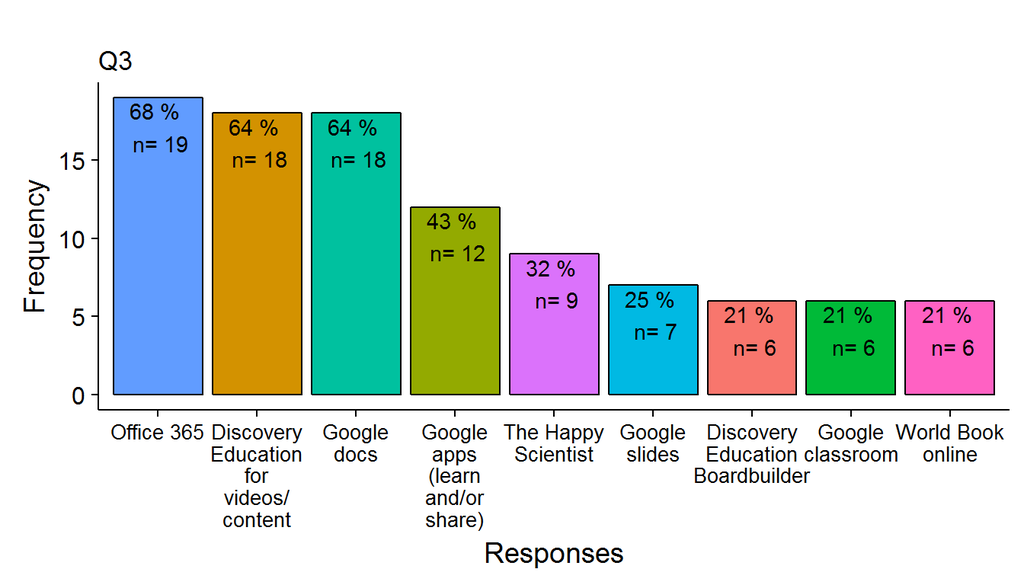

## Question 4

**Which of the following BPS supported Digital Tools would you prefer to receive training on?**

| Q4 Answers | Frequency | Percentage |
| --- | --- | --- |
| Google classroom | 17 | 0.61 |
| Microsoft Moviemaker | 13 | 0.46 |
| Google forms | 12 | 0.43 |
| Google docs | 11 | 0.39 |
| Google apps (learn and/or share) | 8 | 0.29 |
| The Happy Scientist | 6 | 0.21 |
| Discovery Education-for BoardBuilder | 5 | 0.18 |
| Office Mix | 5 | 0.18 |
| Office One Note | 5 | 0.18 |
| Office Sway | 5 | 0.18 |
| World Book online | 5 | 0.18 |
| Discovery Education-for videos/content | 4 | 0.14 |
| Google slides | 4 | 0.14 |
| Animoto | 1 | 0.04 |
| Ebeam programs and free apps for implementation | 1 | 0.04 |
| I clicked all those Office ones simply because I have no idea what they are. | 1 | 0.04 |
| Performance Matters, Premier Literacy Suite | 1 | 0.04 |
| presentations | 1 | 0.04 |
| Prezi | 1 | 0.04 |

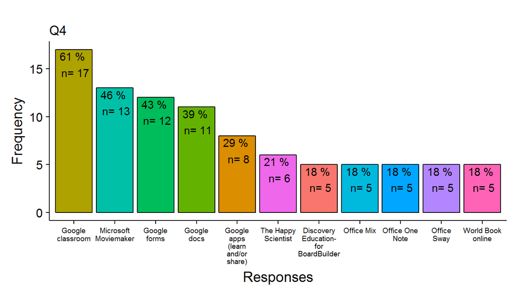

## Question 5

**Based on the previous question, what would you say is a priority for you to receive training on first?**

| Q5 Answers | Frequency | Percentage |
| --- | --- | --- |
| Google classroom | 10 | 0.36 |
| Google Apps | 4 | 0.14 |
| Microsoft Moviemaker | 4 | 0.14 |
| Google forms | 3 | 0.11 |
| Different and new kinds of technology avaliable for me and my students to use in the classroom. | 1 | 0.04 |
| Google Classroom uses for music! | 1 | 0.04 |
| Google docs | 1 | 0.04 |
| Haven’t heard of either, but I feel like they are related? | 1 | 0.04 |
| I just need the time to play with them without distractions. Jodi has done a great job training the kids as well as us | 1 | 0.04 |
| K-2 Free apps for Ipads, Ebeam Primary ideas, Whether we have authorization to download apps on IPADs etc | 1 | 0.04 |
| Microsoft moviemaker | 1 | 0.04 |
| Premier Literacy Suite | 1 | 0.04 |
| The Happy Scientist | 1 | 0.04 |

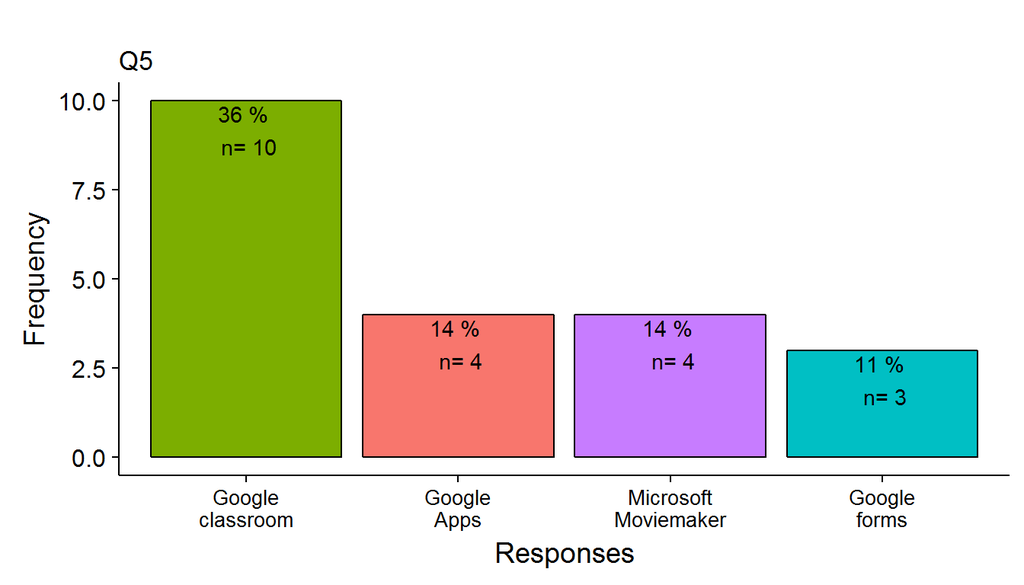

## Question 6

**When would technology training on the above mentioned Digital Tool be most convenient for you?**

| Q6 Answers | Frequency | Percentage |
| --- | --- | --- |
| Wednesdays at early release | 21 | 0.75 |
| During a faculty meeting | 12 | 0.43 |
| During planning | 7 | 0.25 |
| Optional after school (bi-weekly) | 6 | 0.21 |

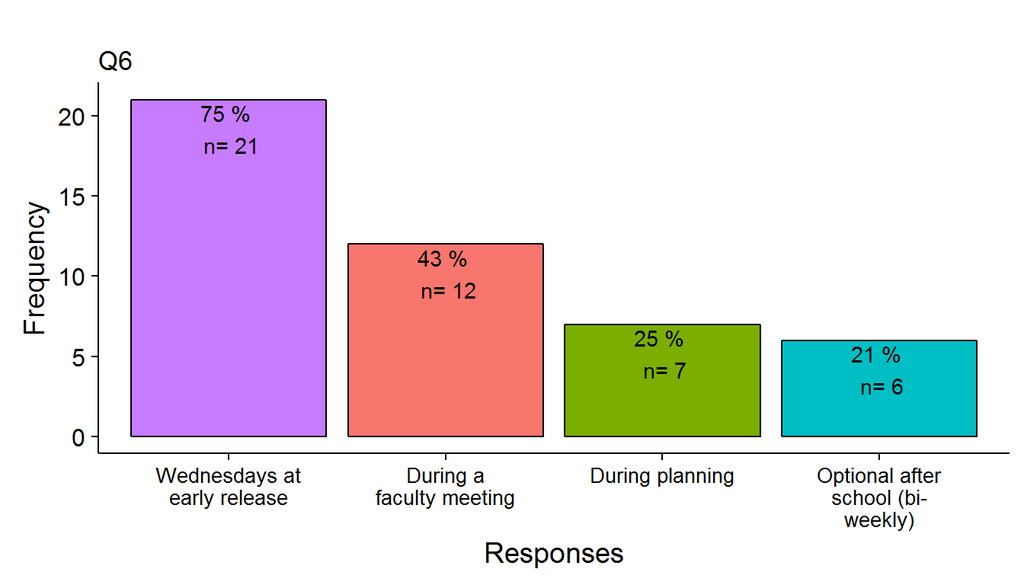

## Question 7

**What type of Digital Projects that you believe incorporate technology creatively do your students CURRENTLY create using any of the BPS Digital Tools?**

|  | Q7 Answers |
| --- | --- |
| 1 | Boardbuilder for SS reports, Google slides for presentations |
| 2 | None using BPS Digital Tools; not user friendly for younger students |
| 3 | Creating prezis detailing information that they have learned from a text. |
| 4 | NA |
| 5 | The students research a topic and create a presentation with any tool learned. |
| 6 | Photo Stories, Videos |
| 7 | My students are using technology to read books - IStation, Tumblebooks, Xtra math |
| 8 | My students use an app called Show Me on the iPad. |
| 9 | stop motion shorts |
| 10 | None |
| 11 | google share/learn |
| 12 | Powerpoint lessons that include speaking and listening, reading, social studies content. Sharing of writing stories, Justification of math answers, songs written on content area or concepts-Doc cam |
| 13 | Google classroom - Science fair |
| 14 | None |
| 15 | My students create writing projects using the show me app on ipads. |
| 16 | I currently create sways, and sways. |
| 17 | Boardbuilder |
| 18 | Using Power Point to write and illustrate stories |
| 19 | Boardbuilder, Google Slides, Prezi, Animoto, IMovie |
| 20 | animoto, google slides, powerpoint |
| 21 | Slides |
| 22 | presentations using google slides, research on line and saving on googledocs |
| 23 | My students do not currently create digital projects in math at this time |
| 24 | They create performance recordings on the IPAd and movie maker app. |
| 25 | Google Docs Reports and Google Slides Presentations, Animoto presentations |
| 26 | Google Slides |
| 27 | My students create presentations using Google Docs, Google Slides, and Microsoft Sway. In addition, my students answer questions using Google Classroom. My students have completed research reports usi… |
| 28 | Creating student generated math tutorials. |

| WORD | FREQ |
| --- | --- |
| google | 13 |
| slides | 9 |
| students | 9 |
| create | 6 |
| presentations | 5 |
| math | 4 |
| animoto | 3 |
| app | 3 |
| boardbuilder | 3 |
| reports | 3 |
| research | 3 |
| stories | 3 |

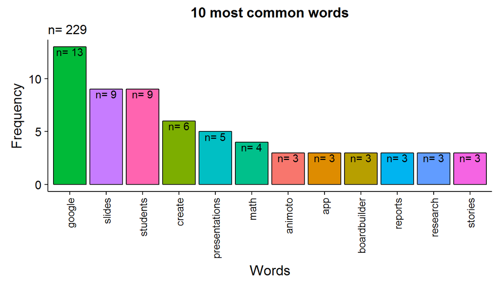

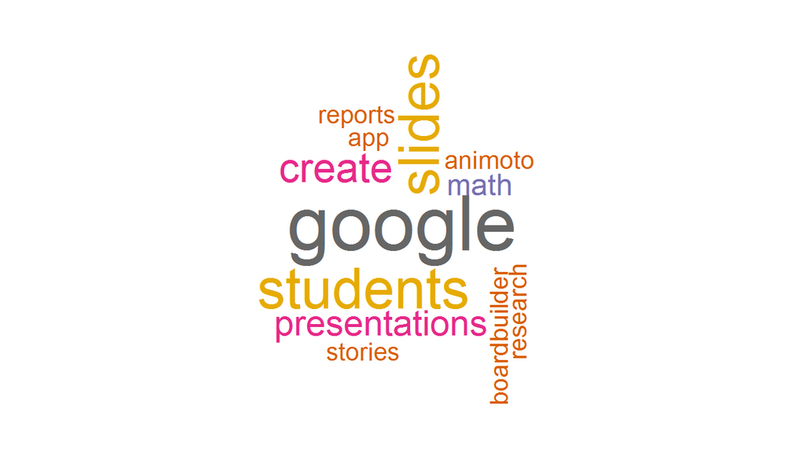

## Question 8

**What type of Digital Projects that you believe incorporate technology creatively WOULD your students create using any of the BPS Digital Tools if you had a 1:1 student to laptop ratio?**

|  | Q8 Answers |
| --- | --- |
| 1 | Movies using Movie Maker; Sway presentations |
| 2 | Google forms, google slides |
| 3 | Research projects, stories, informational books/newsletters, digital storytelling, other |
| 4 | None |
| 5 | Same as #7. They also would benefit from learning to type properly :) |
| 6 | Videos and Public Service Announcements for CCTV |
| 7 | They would be able to use technology for word work activities, creating stories, writing stories, etc. |
| 8 | I believe they could use google classrooms and documents to work on projects together. |
| 9 | endless…presentations, prezis, stop motion films, interviews, etc. |
| 10 | None |
| 11 | google share/learn |
| 12 | I could have students recording their individual reading and fluency. They could then watch themselves to evaluate and work on their individual feedback and progress. They could then have a recording … |
| 13 | Moviemaker |
| 14 | None |
| 15 | I could have all of my students work on show me at the same time in order to publish their writing. |
| 16 | I would create Microsoft moviemaker, and board builder. |
| 17 | Google Classroom, Microsoft Moviemaker |
| 18 | Story summaries using movie maker |
| 19 | Access to programs to practice and use skills and strategies. Google Docs/Classrooms. Presentations |
| 20 | movie maker. google slides |
| 21 | docs/ forms |
| 22 | movies, more projects using current affairs since technology will be readily available |
| 23 | they would create games for students to review concepts, movies to teach a concept and flip a classroom |
| 24 | Research projects embedded with music clips/photos for better understanding/sharing of knowledge on composers and history of music. |
| 25 | Instead of working with partners or teams, a 1:1 ratio would enable the students to collaborate more online when doing projects in Google Slides and Google Docs Reports. At this time without a 1:1 rat… |
| 26 | Google Classroom, SWAY, Google Slides, Google Forms, Discovery Board Builder, Google Docs, video making, Kahoot, quizlet etc… |
| 27 | Presentation of learned material using Board Builder or Microsoft Sway. Jigsaw to teach material using Google Docs, Google Draw, Google Slides, or Microsoft Sway. |
| 28 | More research, compare/contrast projects, finding evidence in solving problems. |

| WORD | FREQ |
| --- | --- |
| google | 16 |
| students | 9 |
| projects | 6 |
| slides | 5 |
| docs | 4 |
| microsoft | 4 |
| research | 4 |
| sway | 4 |
| technology | 4 |
| work | 4 |

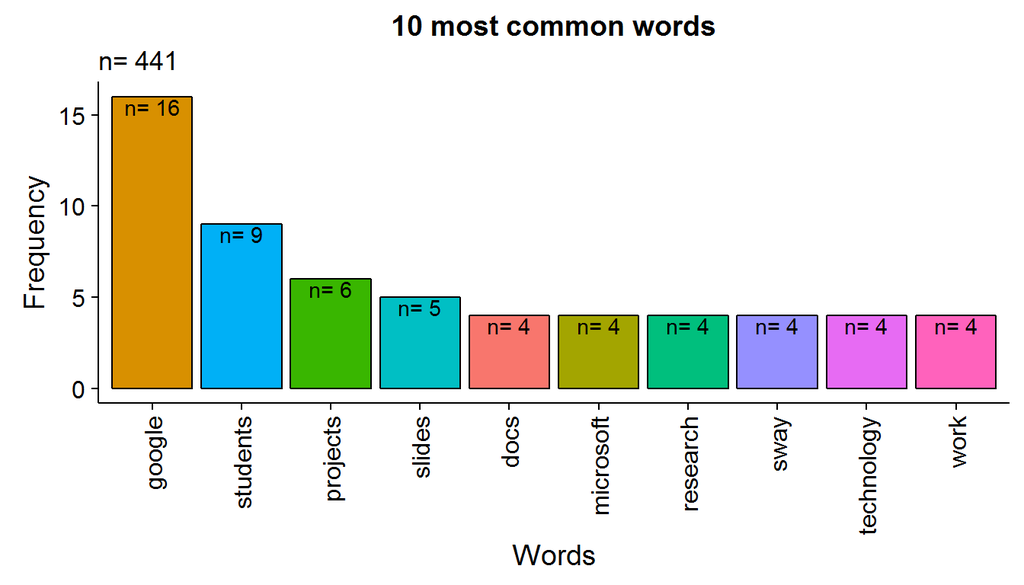

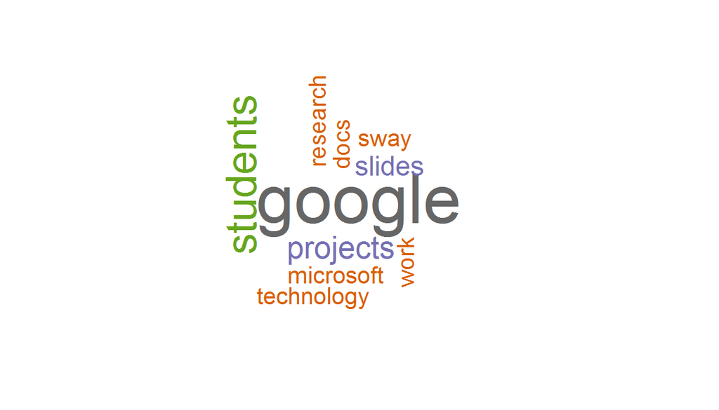

## Question 9

**What Digital Needs do you have in order to make these Digital Projects a success?**

|  | Q9 Answers |
| --- | --- |
| 1 | training on MovieMaker |
| 2 | An easier way to login students into the wifi on tablets |
| 3 | Training, time to implement and more devices. |
| 4 | None |
| 5 | I like the 1 to 1 idea |
| 6 | More devices |
| 7 | Technology that works everyday. Ipads that have apps for my students to use. |
| 8 | 1:1 student to laptop ratio. |
| 9 | that depends - if we don’t have 1:1 computers then I don’t have any digital needs because it is hard to make the projects a success. |
| 10 | Laptops/Desktops |
| 11 | google share/learn |
| 12 | Having tools not tied up to FAIR testing, IStation, and FSA makes more flexibiliity and greater potential for project possibilities |
| 13 | training |
| 14 | None |
| 15 | More I pads and lap tops. |
| 16 | more laptops for each student |
| 17 | enough laptops for each student |
| 18 | More mini Ipads (I have two, it would be nice to have at least 4 more.) |
| 19 | Laptops and Ipads |
| 20 | discovery, google classroom |
| 21 | laptops with longer battery life for use through out the day. |
| 22 | We do not have enough computers. We need enough computers so that they are readily available to all our students. |
| 23 | access to laptops daily |
| 24 | I pads or lap tops. |
| 25 | More laptops, iPads, tablets. Training on how to use digital assessment tools to tally 88 responses in a quicker manner. |
| 26 | I need laptops for each student, time and training |
| 27 | I need 7 additional laptops to have 1 to 1 computer to student ratio. To have 1 to 1 laptop ratio I would need 12 laptops. For each laptop I need mice. I have been purchasing mice from Ebay and Goodwi… |
| 28 | 22 computer laptops with efficient Wi-Fi access |

| WORD | FREQ |
| --- | --- |
| laptops | 10 |
| need | 5 |
| student | 5 |
| training | 5 |
| ipads | 4 |
| students | 4 |
| computers | 3 |
| enough | 3 |
| laptop | 3 |
| mice | 3 |
| ratio | 3 |
| use | 3 |

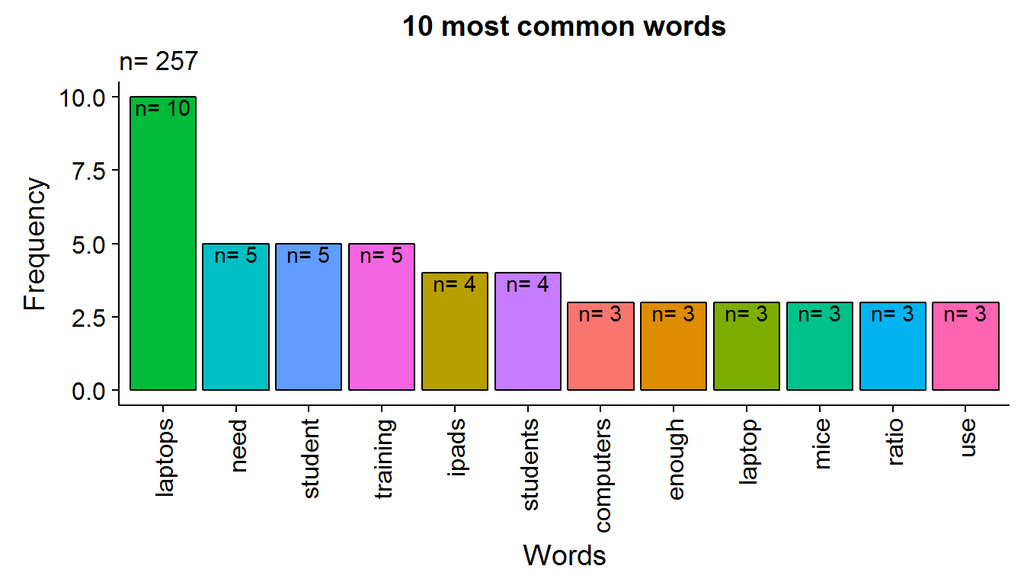

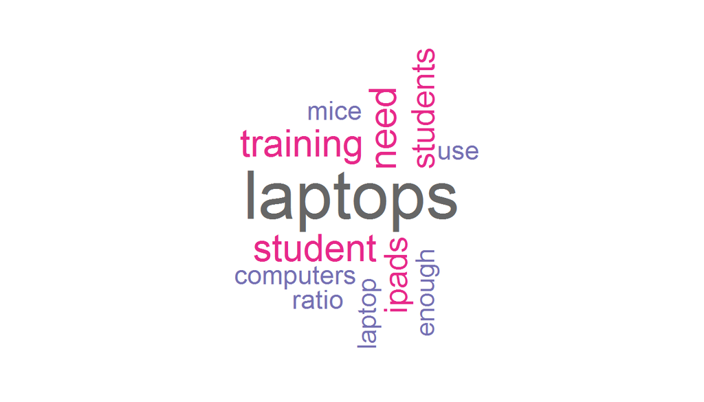

## Question 10

**Are you familiar with Blended Learning?**

Table 13.

| Q10 Answers | Frequency | Percentage |
| --- | --- | --- |
| No | 14 | 0.50 |
| Somewhat | 10 | 0.36 |
| Yes | 4 | 0.14 |

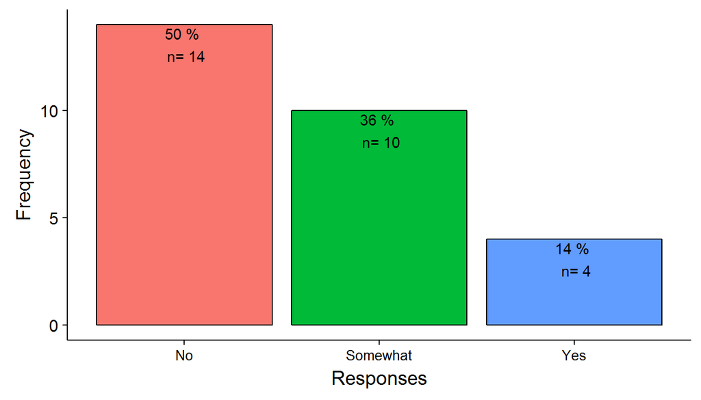

## Question 11

**Would you be willing to be a part of a technology committee at our school?**

Table 14.

| Q11 Answers | Frequency | Percentage |
| --- | --- | --- |
| No | 16 | 0.57 |
| Yes | 10 | 0.36 |

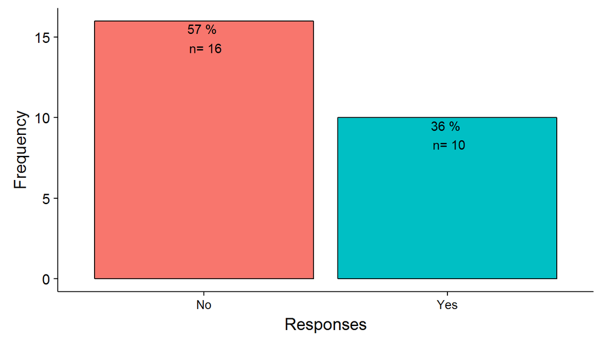

## Question 12

**Are you interested in a technology integrator conducting a workshop on some innovative ways to integrate technology?**

Table 15.

| Q12 Answers | Frequency | Percentage |
| --- | --- | --- |
| Yes | 19 | 0.68 |
| No | 9 | 0.32 |

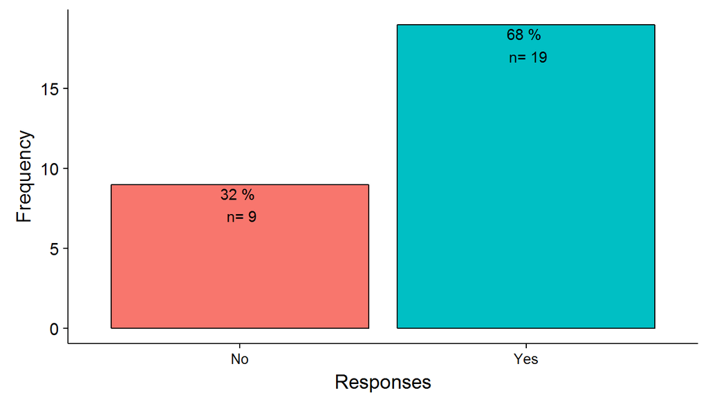

## Further Analysis

**Word Analysis of Questions 3 and 4 combined.**

| WORD | FREQ |
| --- | --- |
| google | 25 |
| discovery | 24 |
| education | 24 |
| office | 22 |
| cgoogle | 19 |
| docs | 18 |
| videoscontent | 18 |
| learn | 13 |
| andor | 12 |
| apps | 12 |
| share | 12 |
| happy | 9 |
| scientist | 9 |
| classroom | 7 |
| slides | 7 |
| boardbuilder | 6 |
| book | 6 |
| online | 6 |
| world | 6 |
| sway | 4 |

| WORD | FREQ |
| --- | --- |
| google | 36 |
| classroom | 17 |
| cgoogle | 16 |
| office | 15 |
| microsoft | 13 |
| moviemaker | 13 |
| forms | 12 |
| docs | 11 |
| apps | 9 |
| discovery | 9 |
| educationfor | 9 |
| andor | 8 |
| learn | 8 |
| share | 8 |
| happy | 6 |
| scientist | 6 |
| boardbuilder | 5 |
| book | 5 |
| mix | 5 |
| note | 5 |
| one | 5 |
| online | 5 |
| sway | 5 |
| world | 5 |

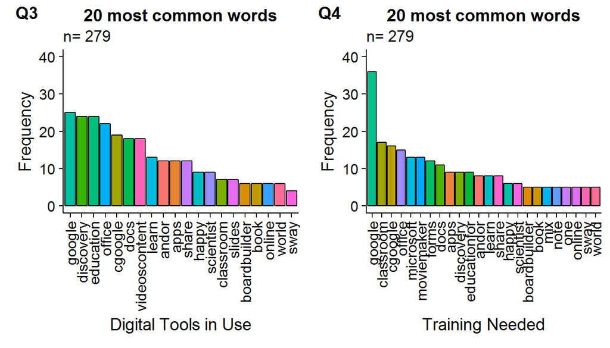

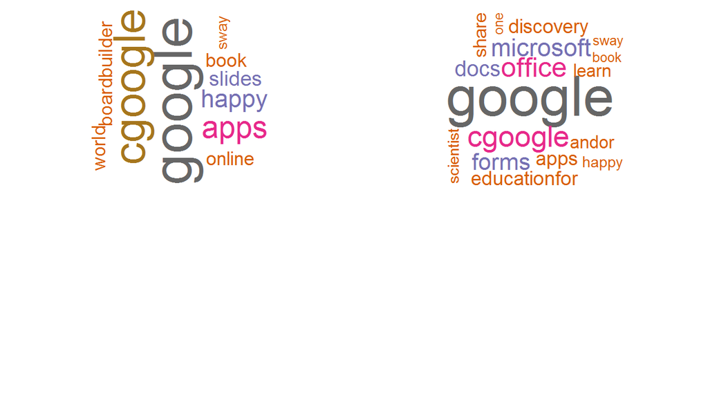

| WORD | FREQ |
| --- | --- |
| google | 31 |
| students | 22 |
| slides | 14 |
| laptops | 11 |
| projects | 9 |
| create | 8 |
| presentations | 7 |
| research | 7 |
| student | 7 |
| use | 7 |
| classroom | 6 |
| docs | 6 |
| microsoft | 6 |
| stories | 6 |
| sway | 6 |
| technology | 6 |
| digital | 5 |
| ipads | 5 |
| need | 5 |
| ratio | 5 |
| time | 5 |

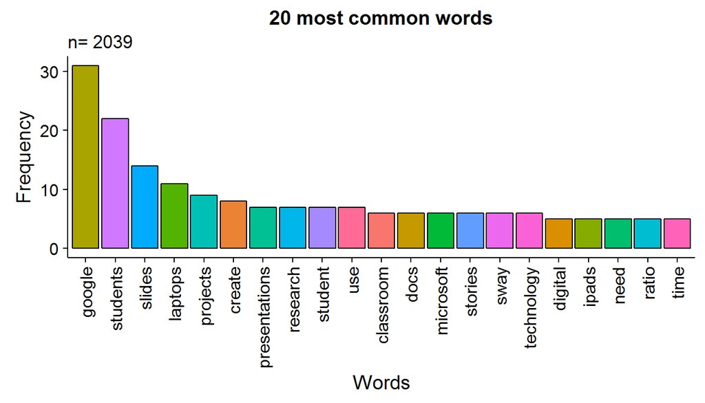

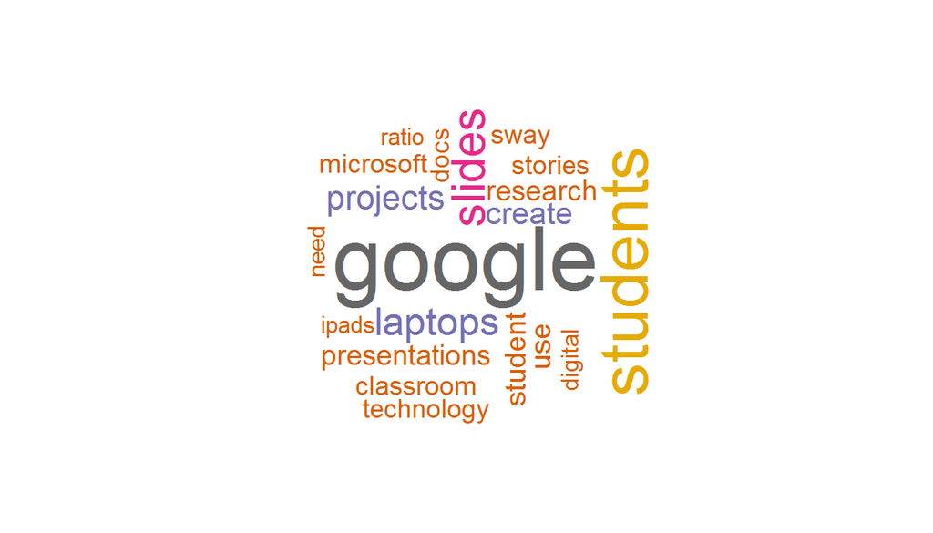